Copyright Jean-Luc CHARLES $-$ 2025/03/14 $-$ CC BY-SA 4.0 $-$

# Training Reproducibility with tensorflow

It is fundamental to use a Python Virtual Environment (PVE) for each important Python project: the PVE makes it possible to control for each project the versions of the Python interpreter and "sensitive" modules (like tensorflow for example).

Notebook tested with tensorflow 2.16.2

## 1 - Import the required Python modules

```python
import os
os.environ['TF_CPP_MIN_LOG_LEVEL'] = '3' #suppress the numerous TensorFlow warnings

import tensorflow as tf
from tensorflow import keras

import sys
import matplotlib.pyplot as plt
import numpy as np
import cv2
from time import time
from cpuinfo import get_cpu_info

from sklearn.metrics import confusion_matrix, classification_report
from sklearn.model_selection import train_test_split

# specific modules:
from utils.tools import scan_dir, plot_images, plot_loss_accuracy, elapsed_time_since, show_conf_matrix, plot_proportion_bar

print(f"Python    : {sys.version.split()[0]}")
print(f"tensorflow: {tf.__version__} with keras {keras.__version__}")
print(f"numpy     : {np.__version__}")
print(f"OpenCV    : {cv2.__version__}")
```

```
Python    : 3.12.3
tensorflow: 2.16.2 with keras 3.8.0
numpy     : 1.26.4
OpenCV    : 4.11.0
```

```python
# allows to visualize the graphs directly in the cell of the notebook:
%matplotlib inline
```

Unless explicitly stated, we use this seed value to make reproducible the random generators:

```python
SEED = 1234
```

## 2 - Reproducibility of pseudo-random generators

The weights of a neural network are initialized by **random values** : when pseudo-random generators are invoked several times in succession, different random sequence are created at each invocation. For example with `numpy.random.rand`:

```python
import numpy as np
for _ in range(5):
    print(np.random.rand(6))
```

```
[0.23493739 0.76102963 0.6163728  0.58231682 0.9925614  0.27800839]
[0.96079441 0.09656961 0.56277576 0.70217628 0.3453946  0.48894639]
[0.03601029 0.08839805 0.67255173 0.619262   0.63483661 0.48512226]
[0.54650105 0.70594616 0.85036756 0.00717569 0.17984199 0.40838755]
[0.29959909 0.09436923 0.67575825 0.4476994  0.41385407 0.55519643]
```

This behavior can be very inappropriate when studying the performance of a trained network as a function of hyperparameters:  
every time you run the training of the neural network (runing the cell or the notebook) with different values of the hyperparameters, you get a different initial state of the network, leading to a different training network...

### The seed of random generators

The technical solution to get a reproducible random sequence from a (pseudo) random generator is to set the **seed** of the generator.

The following cells illustrate the mechanism:

```python
for _ in range(5):
    np.random.seed(1234)
    print(np.random.rand(5))
```

```
[0.19151945 0.62210877 0.43772774 0.78535858 0.77997581]
[0.19151945 0.62210877 0.43772774 0.78535858 0.77997581]
[0.19151945 0.62210877 0.43772774 0.78535858 0.77997581]
[0.19151945 0.62210877 0.43772774 0.78535858 0.77997581]
[0.19151945 0.62210877 0.43772774 0.78535858 0.77997581]
```

Setting the **seed** ensure that the random sequence is the same even on other computers (Windows, Mac, Linux...).  
The figure bellow comes from a Windows10 machine :

[figure not shown]

Of course if you change the seed you get a different random sequence:

```python
for _ in range(5):
    np.random.seed(2345)
    print(np.random.rand(5))
```

```
[0.66064431 0.41360065 0.66810256 0.22994342 0.80767834]
[0.66064431 0.41360065 0.66810256 0.22994342 0.80767834]
[0.66064431 0.41360065 0.66810256 0.22994342 0.80767834]
[0.66064431 0.41360065 0.66810256 0.22994342 0.80767834]
[0.66064431 0.41360065 0.66810256 0.22994342 0.80767834]
```

## 3 - Load the MNIST dataset (images and labels)

We use the keras `load_data` function to load the data from the MNIST (see [tf.keras.datasets.mnist.load_data](https://www.tensorflow.org/api_docs/python/tf/keras/datasets/mnist/load_data)):

- `im_train`, `lab_train` are the training images and labels,
- `im_valid`, `lab_valid` are the validation images and labels.

```python
(im_train, lab_train), (im_valid, lab_valid) = keras.datasets.mnist.load_data()
```

Let's check the `shape` and `dtype` attributes of the numpy arrays:

```python
print(f"im_train.shape:  {im_train.shape}, dtype: {im_train.dtype}")
print(f"im_valid.shape:  {im_valid.shape}, dtype: {im_valid.dtype}")
print(f"lab_train.shape: {lab_train.shape}, dtype: {lab_train.dtype}")
print(f"lab_vaild.shape: {lab_valid.shape}, dtype: {lab_valid.dtype}")
```

```
im_train.shape:  (60000, 28, 28), dtype: uint8
im_valid.shape:  (10000, 28, 28), dtype: uint8
lab_train.shape: (60000,), dtype: uint8
lab_vaild.shape: (10000,), dtype: uint8
```

### Visualization of images and labels:

The local module `utils.tools` defines the `plot_images` function which can be used to display a grid of MNIST images.  
Let's plot a grid of images 3 x 10 beginning with the 600th image:

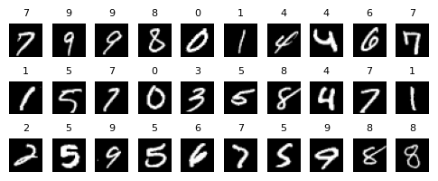

```python
plot_images(im_train, 3, 10, 599, label_array=lab_train)
```

### Create the 3 datasets: train, validation & test

To follow the *state of the art*, we will split the dataset into train, validation & test datasets.  
A simple way to do this is to keep the train dataset and to split the current validation dataset in two equal subsets:

- a new smaller validation subset,
- a new test subset.

```python
# note on train_test_split : Stratified train/test split is not implemented for shuffle=False
# We give the seed value with the 'random_state' parameter to ensure a reproducible splitting.

im_valid, im_test, lab_valid, lab_test = train_test_split(im_valid, lab_valid,
                                                          stratify=lab_valid,
                                                          test_size=0.5,
                                                          shuffle=True,
                                                          random_state=SEED)
```

Let's check the sizes of the 3 datasets:

```python
print(f'train:  {im_train.shape}')
print(f'valid:  {im_valid.shape}')
print(f'test :  {im_test.shape}')
```

```
train:  (60000, 28, 28)
valid:  (5000, 28, 28)
test :  (5000, 28, 28)
```

We can verify that the proportion of digits remains homogenous in all the datasets:

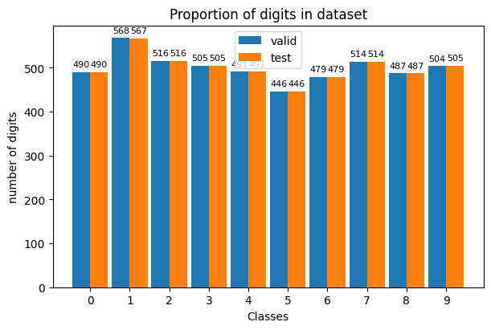

```python
prop = {}
prop['valid'] = [ (lab_valid == i).sum() for i in range(10)]
prop['test']  = [ (lab_test  == i).sum() for i in range(10)]
plot_proportion_bar(prop, range(10))
```

## 4 - Pre-process input dataset

### Setting useful parameters:

To avoid hard-coding the number of training, validation & test images as well as the size of the images, these numbers are recovered from the data set:

- with the shape attribute of the image arrays;
- with the size attribute of the first training image for example.

```python
# number of images in the 3 sets:
NB_IM_TRAIN = im_train.shape[0]
NB_IM_VALID = im_valid.shape[0]
NB_IM_TEST  = im_test.shape[0]
# number of pixels:
NB_PIXEL = im_train[0].size

# number of classes:
NB_CLASS = len(set(lab_train))

# image shape:
IM_SHAPE = im_train[0].shape

# check:
print(f'{NB_IM_TRAIN=}, {NB_IM_VALID=}, {NB_IM_TEST=}, {NB_PIXEL=}')
print(f'{NB_CLASS} different classes found in the `lab_train` ndarray')
print(f'Image size: {IM_SHAPE}')
```

```
NB_IM_TRAIN=60000, NB_IM_VALID=5000, NB_IM_TEST=5000, NB_PIXEL=784
10 different classes found in the `lab_train` ndarray
Image size: (28, 28)
```

Two treatments must be applied to the data from the MNIST database:

- on the images: transform the matrices of 28$\,\times\,$28 pixels (`uint8`integers) into **normalized** vectors $(V_i)_{i=0..783}$ of 784 real values $V_i$ with $ 0 \leqslant V_i \leqslant 1$;
- on labels: transform scalar numbers into *one-hot* vectors.

### Transform input matrices into normalized vectors

We define the arrays `x_train`, `x_valid` and `x_test` containing the matrices of the arrays `im_train`, `im_valid` and `im_test` *flattened* as normalized vectors (values between 0 and 1):

```python
x_train = im_train.reshape(NB_IM_TRAIN, NB_PIXEL)/255
x_valid = im_valid.reshape(NB_IM_VALID, NB_PIXEL)/255
x_test  = im_test.reshape(NB_IM_TEST, NB_PIXEL)/255

#check:
print(f'train: {x_train.shape}, min: {x_train.min()}, max: {x_train.max()}')
print(f'valid: {x_valid.shape}, min: {x_valid.min()}, max: {x_valid.max()}')
print(f'test : {x_test.shape}, min: {x_test.min()}, max: {x_test.max()}')
```

```
train: (60000, 784), min: 0.0, max: 1.0
valid: (5000, 784), min: 0.0, max: 1.0
test : (5000, 784), min: 0.0, max: 1.0
```

### *one-hot* encoding of labels:

We use the **keras** `to_categorical` function (see [tf.keras.utils.to_categorical](https://www.tensorflow.org/api_docs/python/tf/keras/utils/to_categorical)) to define the `y_train` and `y_valid` arrays containing the *hot-one* encoded version of `lab_train` and `lab_valid`:

```python
from tensorflow.keras.utils import to_categorical
# 'one-hot' encoding' of labels :
y_train = to_categorical(lab_train)
y_valid = to_categorical(lab_valid)
```

Let's check the first 10 values of the `lab_train` and `y_train` arrays:

```python
print(lab_train[:10])
print(y_train[:10])
```

```
[5 0 4 1 9 2 1 3 1 4]
[[0. 0. 0. 0. 0. 1. 0. 0. 0. 0.]
 [1. 0. 0. 0. 0. 0. 0. 0. 0. 0.]
 [0. 0. 0. 0. 1. 0. 0. 0. 0. 0.]
 [0. 1. 0. 0. 0. 0. 0. 0. 0. 0.]
 [0. 0. 0. 0. 0. 0. 0. 0. 0. 1.]
 [0. 0. 1. 0. 0. 0. 0. 0. 0. 0.]
 [0. 1. 0. 0. 0. 0. 0. 0. 0. 0.]
 [0. 0. 0. 1. 0. 0. 0. 0. 0. 0.]
 [0. 1. 0. 0. 0. 0. 0. 0. 0. 0.]
 [0. 0. 0. 0. 1. 0. 0. 0. 0. 0.]]
```

## 5 - Build the Dense Neural Network (DNN)

To get short computation times we build a simple dense network to classify the MNIST images.  
Of course, this is not the "state of the art" : convolutive NN, transformers have much more impressive scores, but we just want want short training computation time.  
We buildthis naive **dense network**:

- an **input layer** of 784 values (the pixels of the MNIST 28 $\times$ 28 images flattened in the form of a vector of 784 normalized `float` numbers),
- a **hidden layer** of 784 neurons using the `relu` activation function,
- an **output layer** of 10 neurons, for the classification of the 10 digits {0,1,2...9}, using the `softmax` activation function adapted to classification problems .

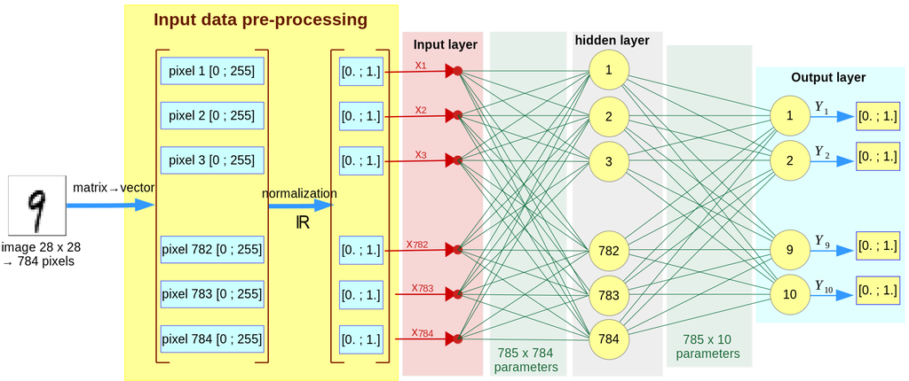

[image credit: JLC]

```python
NB_INPUT  = NB_PIXEL
NB_NEURON = NB_PIXEL
```

For the sake of convenience we défine a function to build the NN:

```python
from tensorflow.keras.models import Sequential
from tensorflow.keras.layers import Dense, Input

def build_DNN(seed=None):

    if seed is not None:
        ##########################
        # Deterministic training #
        ##########################
        # 1/ set the seed of the random generators involved by tensorflow:
        tf.keras.utils.set_random_seed(seed)
        # 2/ make the tf ops determinisctic
        # [see https://blog.tensorflow.org/2022/05/whats-new-in-tensorflow-29.html]
        tf.config.experimental.enable_op_determinism()

    model = Sequential()
    model.add(Input(shape=(NB_INPUT,), name='input'))             # INPUT layer
    model.add(Dense(NB_NEURON, activation='relu', name='c1'))     # First hidden layer
    model.add(Dense(NB_CLASS, activation='softmax', name='c2'))   # OUTPUT layer
    model.compile(loss='categorical_crossentropy', optimizer='adam',  metrics=['accuracy'])
    return model
```

Lets's look at the number of *parameters* (the *weights*) of the model:

```python
model = build_DNN()
model.summary()
```

```
Model: "sequential"
```

```
┏━━━━━━━━━━━━━━━━━━━━━━━━━━━━━━━━━┳━━━━━━━━━━━━━━━━━━━━━━━━┳━━━━━━━━━━━━━━━┓
┃ Layer (type)                    ┃ Output Shape           ┃       Param # ┃
┡━━━━━━━━━━━━━━━━━━━━━━━━━━━━━━━━━╇━━━━━━━━━━━━━━━━━━━━━━━━╇━━━━━━━━━━━━━━━┩
│ c1 (Dense)                      │ (None, 784)            │       615,440 │
├─────────────────────────────────┼────────────────────────┼───────────────┤
│ c2 (Dense)                      │ (None, 10)             │         7,850 │
└─────────────────────────────────┴────────────────────────┴───────────────┘
```

```
 Total params: 623,290 (2.38 MB)
```

```
 Trainable params: 623,290 (2.38 MB)
```

```
 Non-trainable params: 0 (0.00 B)
```

## 6 - Elementary tests of the reproducibility of the DNN training...

Perfect reproducibility of a neural network training may be difficult to achieve with tensorflow...  
To highlight the question of reproducibility we run a short experiment: run a loop where the model is built without setting the seed, trained and evaluated once (*epochs=1*) at each iteration.

#### A/ If we don't set the tensorflow seed, the training is not reproducible:

```python
print(get_cpu_info()['brand_raw'])
for _ in range(5):
    model = build_DNN()  # Build a new model without setting seed
    hist = model.fit(x_train, y_train, epochs=1, batch_size=32, validation_data=(x_valid, y_valid), verbose=2)
```

```
Intel(R) Xeon(R) W-1390P @ 3.50GHz
1875/1875 - 5s - 3ms/step - accuracy: 0.9437 - loss: 0.1917 - val_accuracy: 0.9654 - val_loss: 0.1050
1875/1875 - 4s - 2ms/step - accuracy: 0.9432 - loss: 0.1902 - val_accuracy: 0.9690 - val_loss: 0.0974
1875/1875 - 4s - 2ms/step - accuracy: 0.9424 - loss: 0.1908 - val_accuracy: 0.9698 - val_loss: 0.0988
1875/1875 - 4s - 2ms/step - accuracy: 0.9441 - loss: 0.1899 - val_accuracy: 0.9690 - val_loss: 0.0957
1875/1875 - 4s - 2ms/step - accuracy: 0.9428 - loss: 0.1907 - val_accuracy: 0.9690 - val_loss: 0.0962
```

In these cells we must focus on the metrics `val_accuracy`and `val_loss` to evaluate the training after one epoch: we see that if we repeat 5 times the first epoch of the training, the `val_accuracy`and `val_loss` values differ at each iteration $\leadsto$ the training is not reproducible.

```python
print(get_cpu_info()['brand_raw'])
for _ in range(5):
    model = build_DNN()  # Build a new model without setting seed
    hist = model.fit(x_train, y_train, epochs=1, batch_size=16, validation_data=(x_valid, y_valid), verbose=2)
```

```
Intel(R) Xeon(R) W-1390P @ 3.50GHz
3750/3750 - 7s - 2ms/step - accuracy: 0.9453 - loss: 0.1810 - val_accuracy: 0.9616 - val_loss: 0.1149
3750/3750 - 7s - 2ms/step - accuracy: 0.9458 - loss: 0.1787 - val_accuracy: 0.9688 - val_loss: 0.1083
3750/3750 - 8s - 2ms/step - accuracy: 0.9463 - loss: 0.1785 - val_accuracy: 0.9634 - val_loss: 0.1137
3750/3750 - 7s - 2ms/step - accuracy: 0.9451 - loss: 0.1815 - val_accuracy: 0.9700 - val_loss: 0.0886
3750/3750 - 8s - 2ms/step - accuracy: 0.9457 - loss: 0.1791 - val_accuracy: 0.9722 - val_loss: 0.0873
```

In the celle above, we changed the `batch_size`from 32 to 16 $\leadsto$ the training is still not reproducible.

#### B/ If we just reload the inital network the training is not reproducible:

We save the weights of a model built without setting the seed:

```python
model = build_DNN()
model.save_weights('weights/DNN_noseed.weights.h5')
```

```python
print(get_cpu_info()['brand_raw'])
model = build_DNN()
for _ in range(5):
    model.load_weights('weights/DNN_noseed.weights.h5') # reload the inital model weights
    hist = model.fit(x_train, y_train, epochs=1, batch_size=16, validation_data=(x_valid, y_valid), verbose=2)
```

```
Intel(R) Xeon(R) W-1390P @ 3.50GHz
3750/3750 - 7s - 2ms/step - accuracy: 0.9462 - loss: 0.1793 - val_accuracy: 0.9770 - val_loss: 0.0827
3750/3750 - 7s - 2ms/step - accuracy: 0.9487 - loss: 0.1660 - val_accuracy: 0.9752 - val_loss: 0.0850
3750/3750 - 7s - 2ms/step - accuracy: 0.9512 - loss: 0.1597 - val_accuracy: 0.9718 - val_loss: 0.0952
3750/3750 - 7s - 2ms/step - accuracy: 0.9499 - loss: 0.1618 - val_accuracy: 0.9762 - val_loss: 0.0787
3750/3750 - 7s - 2ms/step - accuracy: 0.9499 - loss: 0.1634 - val_accuracy: 0.9638 - val_loss: 0.1094
```

```python
print(get_cpu_info()['brand_raw'])
for _ in range(5):
    model.load_weights('weights/DNN_relu_noseed.weights.h5') # reload the inital model weights
    hist = model.fit(x_train, y_train, epochs=1, batch_size=32, validation_data=(x_valid, y_valid), verbose=2)
```

```
Intel(R) Xeon(R) W-1390P @ 3.50GHz
1875/1875 - 4s - 2ms/step - accuracy: 0.9477 - loss: 0.1725 - val_accuracy: 0.9744 - val_loss: 0.0863
1875/1875 - 4s - 2ms/step - accuracy: 0.9471 - loss: 0.1745 - val_accuracy: 0.9732 - val_loss: 0.0906
1875/1875 - 4s - 2ms/step - accuracy: 0.9476 - loss: 0.1725 - val_accuracy: 0.9708 - val_loss: 0.0919
1875/1875 - 4s - 2ms/step - accuracy: 0.9480 - loss: 0.1711 - val_accuracy: 0.9752 - val_loss: 0.0848
1875/1875 - 4s - 2ms/step - accuracy: 0.9480 - loss: 0.1723 - val_accuracy: 0.9694 - val_loss: 0.1008
```

The `val_loss` is still non-reproducible.

#### C/ If the tensorflow seed is set fthe training is reproducible:

```python
print(get_cpu_info()['brand_raw'])
for _ in range(5):
    model = build_DNN(seed=1234)  # Build a new model with seed set
    hist = model.fit(x_train, y_train, epochs=1, batch_size=16, validation_data=(x_valid, y_valid), verbose=2)
```

```
Intel(R) Xeon(R) W-1390P @ 3.50GHz
3750/3750 - 7s - 2ms/step - accuracy: 0.9457 - loss: 0.1790 - val_accuracy: 0.9688 - val_loss: 0.1067
3750/3750 - 8s - 2ms/step - accuracy: 0.9457 - loss: 0.1790 - val_accuracy: 0.9688 - val_loss: 0.1067
3750/3750 - 9s - 2ms/step - accuracy: 0.9457 - loss: 0.1790 - val_accuracy: 0.9688 - val_loss: 0.1067
3750/3750 - 8s - 2ms/step - accuracy: 0.9457 - loss: 0.1790 - val_accuracy: 0.9688 - val_loss: 0.1067
3750/3750 - 8s - 2ms/step - accuracy: 0.9457 - loss: 0.1790 - val_accuracy: 0.9688 - val_loss: 0.1067
```

If we set the seed when creating the model at each iteration the `val_accuracy`and `val_loss` are perfectly reproducible 😎.

#### D/ If we load the model's structure & initial weights the training is reproducible

```python
model = build_DNN(seed=1234)
model.save('models/DNN_seed1234.keras')
```

```python
print(get_cpu_info()['brand_raw'])
for _ in range(5):
    model = tf.keras.models.load_model('models/DNN_seed1234.keras') # reload the model structure & weights
    hist = model.fit(x_train, y_train, epochs=1, batch_size=16, validation_data=(x_valid, y_valid), verbose=2)
```

[output not shown]

If we load the structure and the weights of the model at each iteration the `val_accuracy`and `val_loss` are perfectly reproducible 😎.

We can ensure the reproducibility of the first epoch of the training:  
$\leadsto$ by setting the seed at the network creation (and everywhere else where required)  
$\leadsto$ or by reloading the entire network structure and weights with the **tf.keras.models.load_model** function

## 6 - Full tests of the reproducibility of the DNN training...

### Run several identical trainings with a new model at each iteration $\leadsto$ not reproducible

Check some important parameters:

```python
print(f'{IM_SHAPE=}')
print(f'{NB_INPUT=}, {NB_NEURON=}, {NB_CLASS=}')
```

```
IM_SHAPE=(28, 28)
NB_INPUT=784, NB_NEURON=784, NB_CLASS=10
```

```
training  #1 #2 #3 #4 #5 Total Train Elapsed time 205s -> 00:03:25
```

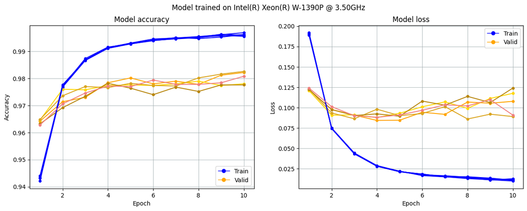

```python
H, t0 = [], time()
print("training ", end="")

for i in range(5):
    print(f" #{i+1}", end="")

    # build a new network/
    model = build_DNN()

    hist = model.fit(x_train, y_train, # images, labels
                     epochs=10,        # the total number of successive trainings
                     batch_size=32,    # fragmentation of the whole dada set in batches
                     validation_data=(x_valid, y_valid),
                     verbose=0)
    H.append(hist)

print(f' Total Train {elapsed_time_since(t0)}')
plot_loss_accuracy(H)
```

The `val_loss` and `val_accuracy` differ at each of the training.  
It can be a problem if we use a *callback* like **early stoppping** : the training will stop at a different epoch if we run the training many times.

### Load the same model weights at each iteration $\leadsto$ not reproducible

```
training  #1 #2 #3 #4 #5 Total Train Elapsed time 205s -> 00:03:25
```

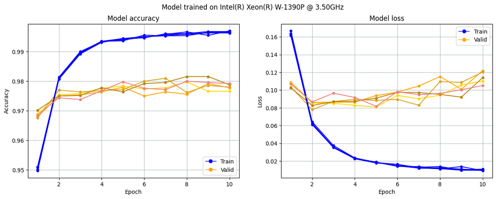

```python
H, t0 = [], time()
print("training ", end="")

for i in range(5):
    print(f" #{i+1}", end="")

    # reload the structure of the NN and its initial state
    model.load_weights('weights/DNN_noseed.weights.h5')

    # train the network
    hist = model.fit(x_train, y_train,
                     epochs=10,
                     batch_size=32,
                     validation_data=(x_valid, y_valid),
                     verbose=0)

    H.append(hist)

print(f' Total Train {elapsed_time_since(t0)}')
plot_loss_accuracy(H)
```

The `val_loss` and `val_accuracy` differ at each training.  
It can be a problem if we use a *callback* like **early stoppping** : the training will stop at a different epoch if we run the training many times.

### Running several identical training with the tensorflow seed set $\leadsto$ reproducible

```
training  #1 #2 #3 #4 #5 Total Train Elapsed time 202s -> 00:03:22
```

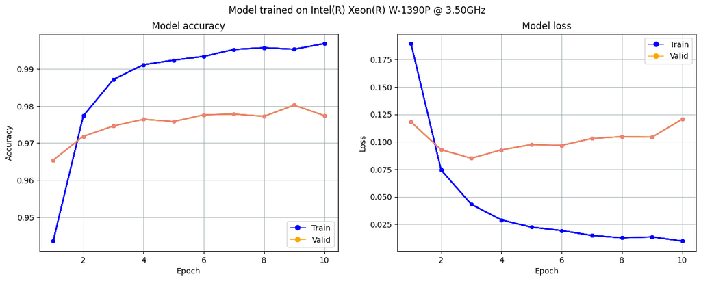

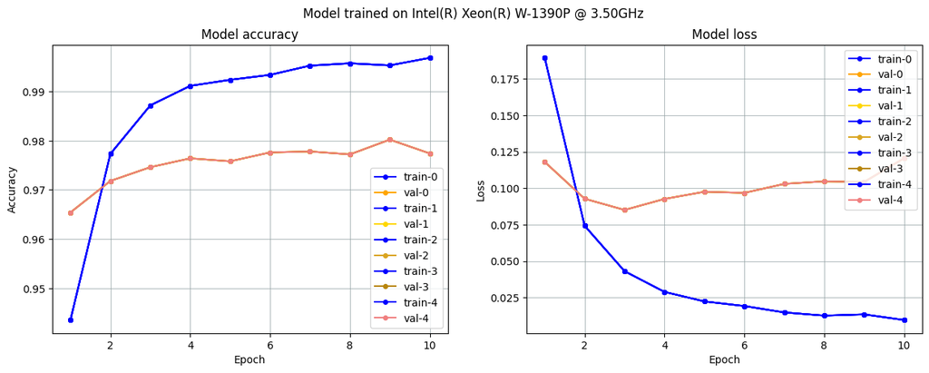

```python
H, t0 = [], time()
print("training ", end="")

for i in range(5):
    print(f" #{i+1}", end="")

    # build a new network/
    model = build_DNN(1234)

    hist = model.fit(x_train, y_train, # images, labels
                     epochs=10,        # the total number of successive trainings
                     batch_size=32,    # fragmentation of the whole dada set in batches
                     validation_data=(x_valid, y_valid),
                     verbose=0)
    H.append(hist)

print(f' Total Train {elapsed_time_since(t0)}')
plot_loss_accuracy(H)
plot_loss_accuracy(H, single_legend=False)
```

$\leadsto$ the repoducibility is perfect 😎

### Running several identical training with reloading the model structure & initial state $\leadsto$ reproducible

```
training  #1 #2 #3 #4 #5 Total Train Elapsed time 191s -> 00:03:11
```

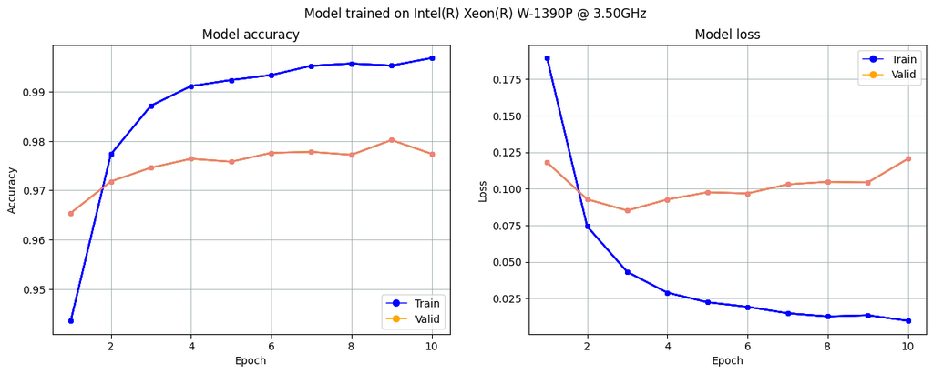

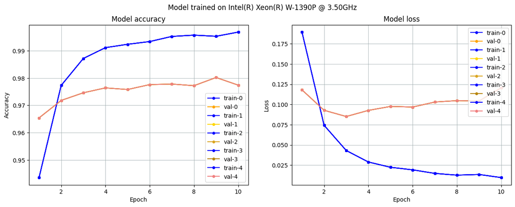

```python
H, t0 = [], time()
print("training ", end="")

for i in range(5):
    print(f" #{i+1}", end="")

    # reload the structure of the NN and its initial state
    model = tf.keras.models.load_model('models/DNN_seed1234.keras')

    # set the seed at each turn of the loop:
    tf.random.set_seed(1234)

    # train the network
    hist = model.fit(x_train, y_train,
                     epochs=10,
                     batch_size=32,
                     validation_data=(x_valid, y_valid),
                     verbose=0)
    H.append(hist)

print(f' Total Train {elapsed_time_since(t0)}')
plot_loss_accuracy(H)
plot_loss_accuracy(H, single_legend=False)
```

Now that the training is reproducible it makes sens to study the influnece of some meta-parameters (n_epoch, batch_size...) on the performance of the trained network.

# Other interesting resources... videos:

```python
%%HTML
<iframe src="https://www.youtube.com/embed/trWrEWfhTVg" width="800" height="450" frameborder="0" allow="accelerometer; autoplay; encrypted-media; gyroscope; picture-in-picture" allowfullscreen></iframe>
```

[video not shown]

```python
%%HTML
<iframe src="https://www.youtube.com/embed/aircAruvnKk" width="800" height="450" frameborder="0" allow="accelerometer; autoplay; encrypted-media; gyroscope; picture-in-picture" allowfullscreen></iframe>
```

[video not shown]

```python
%%HTML
<iframe src="https://www.youtube.com/embed/IHZwWFHWa-w" width="800" height="450" frameborder="0" allow="accelerometer; autoplay; encrypted-media; gyroscope; picture-in-picture" allowfullscreen></iframe>
```

[video not shown]

```python
%%HTML
<iframe src="https://www.youtube.com/embed/Ilg3gGewQ5U" width="800" height="450" frameborder="0" allow="accelerometer; autoplay; encrypted-media; gyroscope; picture-in-picture" allowfullscreen></iframe>
```

[video not shown]